# Logistic Regression with Newton’s Method

## Abstract

Title: Wisconsin Diagnostic Breast Cancer (WDBC)

The Wisconsin Diagnostic Breast Cancer (WDBC) dataset is a well-known and extensively studied dataset in the field of machine learning. It was originally created by Dr. William H. Wolberg, W. Nick Street, and Olvi L. Mangasarian, with the intention of developing a predictive model for breast cancer diagnosis.

The dataset contains 569 instances, each with 32 attributes. These attributes encompass various measurements related to cell nuclei characteristics, including radius, texture, perimeter, area, smoothness, compactness, concavity, concave points, symmetry, and fractal dimension. These features are computed from digitized images of fine needle aspirates (FNA) of breast masses. The data also includes a unique ID number for each instance and a diagnosis label indicating whether the tumor is benign (B) or malignant (M).

Past usage of the dataset includes research in nuclear feature extraction for breast tumor diagnosis and the development of machine learning techniques for breast cancer diagnosis and prognosis. The dataset is known to be linearly separable, and it has been used to train models for distinguishing between benign and malignant tumors. The best predictive accuracy achieved was approximately 97.5% using repeated 10-fold cross-validation.

The dataset has been a valuable resource in the development of classification models for breast cancer diagnosis, and it continues to be a relevant topic of research in the medical and machine learning communities.

Overall, the Wisconsin Diagnostic Breast Cancer dataset provides an excellent opportunity for researchers and machine learning practitioners to work on a real-world medical problem, aiding in the early diagnosis and treatment of breast cancer.

## Importing Necessary Libraries

```python
## Dependencies
import numpy as np
import pandas as pd
import matplotlib.pyplot as mplot
import seaborn as sbn
from sklearn.model_selection import train_test_split
from sklearn.linear_model import LogisticRegression
from sklearn.metrics import accuracy_score
```

## Data Pre-processing

```python
# defining the column names for the data
features = ['id', 'diagnosis', 'radius_mean', 'texture_mean','perimeter_mean','area_mean','smoothness_mean','compactness_mean','concavity_mean','concave_points_mean','symmetry_mean','fractal_dimension_mean','radius_se','texture_se','perimeter_se','area_se','smoothness_se','compactness_se','concavity_se','concave_points_se','symmetry_se','fractal_dimension_se','radius_worst','texture_worst','perimeter_worst','area_worst','smoothness_worst','compactness_worst','concavity_worst','concave_points_worst','symmetry_worst','fractal_dimension_worst']

# import the data from the file and imposing the schema(columns) on top of the data
raw = pd.read_csv('./wdbc.data',
                      header = None,
                      names = features)

# Visualizing
raw.head()
```

|  | id | diagnosis | radius_mean | texture_mean | perimeter_mean | area_mean | smoothness_mean | compactness_mean | concavity_mean | concave_points_mean | ... | radius_worst | texture_worst | perimeter_worst | area_worst | smoothness_worst | compactness_worst | concavity_worst | concave_points_worst | symmetry_worst | fractal_dimension_worst |
| --- | --- | --- | --- | --- | --- | --- | --- | --- | --- | --- | --- | --- | --- | --- | --- | --- | --- | --- | --- | --- | --- |
| 0 | 842302 | M | 17.99 | 10.38 | 122.80 | 1001.0 | 0.11840 | 0.27760 | 0.3001 | 0.14710 | ... | 25.38 | 17.33 | 184.60 | 2019.0 | 0.1622 | 0.6656 | 0.7119 | 0.2654 | 0.4601 | 0.11890 |
| 1 | 842517 | M | 20.57 | 17.77 | 132.90 | 1326.0 | 0.08474 | 0.07864 | 0.0869 | 0.07017 | ... | 24.99 | 23.41 | 158.80 | 1956.0 | 0.1238 | 0.1866 | 0.2416 | 0.1860 | 0.2750 | 0.08902 |
| 2 | 84300903 | M | 19.69 | 21.25 | 130.00 | 1203.0 | 0.10960 | 0.15990 | 0.1974 | 0.12790 | ... | 23.57 | 25.53 | 152.50 | 1709.0 | 0.1444 | 0.4245 | 0.4504 | 0.2430 | 0.3613 | 0.08758 |
| 3 | 84348301 | M | 11.42 | 20.38 | 77.58 | 386.1 | 0.14250 | 0.28390 | 0.2414 | 0.10520 | ... | 14.91 | 26.50 | 98.87 | 567.7 | 0.2098 | 0.8663 | 0.6869 | 0.2575 | 0.6638 | 0.17300 |
| 4 | 84358402 | M | 20.29 | 14.34 | 135.10 | 1297.0 | 0.10030 | 0.13280 | 0.1980 | 0.10430 | ... | 22.54 | 16.67 | 152.20 | 1575.0 | 0.1374 | 0.2050 | 0.4000 | 0.1625 | 0.2364 | 0.07678 |

5 rows × 32 columns

The `diagnosis` field gives us the information whether the given individual is diagnosed with malignant or benign. Let us check if the data present in the field has any ambiguous diagnosis which is not malignant or benign.

```python
raw['diagnosis'].unique() # we can see there is only 'M' and 'B' which is good for us to proceed
```

```
array(['M', 'B'], dtype=object)
```

## Vizualising Correlations Between Features

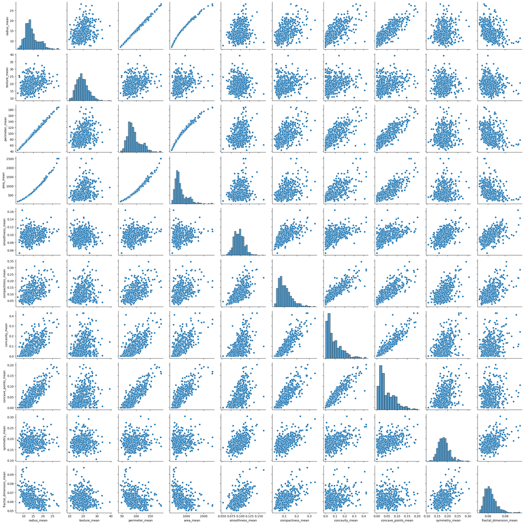

```python
colmns = ['radius_mean', 'texture_mean', 'perimeter_mean', 'area_mean', 'smoothness_mean','compactness_mean','concavity_mean','concave_points_mean','symmetry_mean','fractal_dimension_mean']

sbn.pairplot(raw[colmns], height=2.5)
mplot.tight_layout()
mplot.show()
```

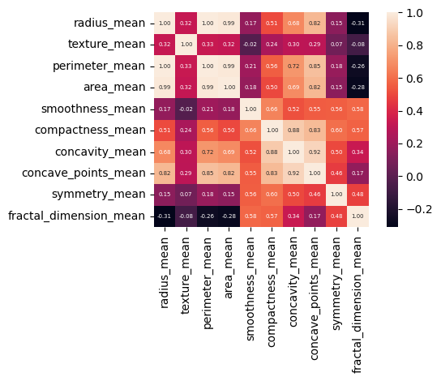

```python
c = np.corrcoef(raw[colmns].values.T)
h = sbn.heatmap(c,
                 cbar=True,
                 annot=True,
                 square=True,
                 fmt='.2f',
                 annot_kws={'size': 5},
                 yticklabels=colmns,
                 xticklabels=colmns)

mplot.tight_layout()
mplot.show()
```

## Analysis Based on Plots

We see that the perimeter and the area are both computed using the radius. If we include them in the models, then there would be a overrepresentation of the radius feature. This is why they must be omitted.

We do not need all the fields for our training the model. Also, since `diagnosis` field is of `character` type definition for malignant and benign, we can provide an integer value for ease of processing.

In logistic regression, you typically use binary class labels, where one class is represented as 0 and the other as 1. We should convert the class labels to a binary representation before training your logistic regression model. Binary class labels are best suitable for logistic regression.

```python
# dropping the unused fields
fields_to_drop = ['id', 'perimeter_mean', 'area_mean']
raw = raw.drop(fields_to_drop, axis=1)

# modifying the target feature to int - 1 for malignant, 0 - for benign
dictionary = {'M': 1, 'B': 0}
raw['diagnosis'] = raw['diagnosis'].map(dictionary)

# Visualising the data again with dropped features
raw.head()
```

|  | diagnosis | radius_mean | texture_mean | smoothness_mean | compactness_mean | concavity_mean | concave_points_mean | symmetry_mean | fractal_dimension_mean | radius_se | ... | radius_worst | texture_worst | perimeter_worst | area_worst | smoothness_worst | compactness_worst | concavity_worst | concave_points_worst | symmetry_worst | fractal_dimension_worst |
| --- | --- | --- | --- | --- | --- | --- | --- | --- | --- | --- | --- | --- | --- | --- | --- | --- | --- | --- | --- | --- | --- |
| 0 | 1 | 17.99 | 10.38 | 0.11840 | 0.27760 | 0.3001 | 0.14710 | 0.2419 | 0.07871 | 1.0950 | ... | 25.38 | 17.33 | 184.60 | 2019.0 | 0.1622 | 0.6656 | 0.7119 | 0.2654 | 0.4601 | 0.11890 |
| 1 | 1 | 20.57 | 17.77 | 0.08474 | 0.07864 | 0.0869 | 0.07017 | 0.1812 | 0.05667 | 0.5435 | ... | 24.99 | 23.41 | 158.80 | 1956.0 | 0.1238 | 0.1866 | 0.2416 | 0.1860 | 0.2750 | 0.08902 |
| 2 | 1 | 19.69 | 21.25 | 0.10960 | 0.15990 | 0.1974 | 0.12790 | 0.2069 | 0.05999 | 0.7456 | ... | 23.57 | 25.53 | 152.50 | 1709.0 | 0.1444 | 0.4245 | 0.4504 | 0.2430 | 0.3613 | 0.08758 |
| 3 | 1 | 11.42 | 20.38 | 0.14250 | 0.28390 | 0.2414 | 0.10520 | 0.2597 | 0.09744 | 0.4956 | ... | 14.91 | 26.50 | 98.87 | 567.7 | 0.2098 | 0.8663 | 0.6869 | 0.2575 | 0.6638 | 0.17300 |
| 4 | 1 | 20.29 | 14.34 | 0.10030 | 0.13280 | 0.1980 | 0.10430 | 0.1809 | 0.05883 | 0.7572 | ... | 22.54 | 16.67 | 152.20 | 1575.0 | 0.1374 | 0.2050 | 0.4000 | 0.1625 | 0.2364 | 0.07678 |

5 rows × 29 columns

## Splitting the Data into Train and Test Sets

```python
# Using 20% data for testing, 10% for Cross Validation
idx_split_test = int(raw.shape[0] * 0.8)
idx_split_val = int(raw.shape[0] * 0.7)

testing_dataset = raw[idx_split_test:] #test_data
validation_dataset = raw[idx_split_val:idx_split_test] #val_data
data = raw[:idx_split_val]

# Separating data to features and targets
train_Y, train_X = data['diagnosis'], data.drop('diagnosis', axis = 1)
val_Y, val_X = validation_dataset['diagnosis'], validation_dataset.drop('diagnosis', axis = 1)
test_Y, test_X = testing_dataset['diagnosis'], testing_dataset.drop('diagnosis', axis = 1)
```

```python
## Visualising the training dataset
train_X.head()
```

|  | radius_mean | texture_mean | smoothness_mean | compactness_mean | concavity_mean | concave_points_mean | symmetry_mean | fractal_dimension_mean | radius_se | texture_se | ... | radius_worst | texture_worst | perimeter_worst | area_worst | smoothness_worst | compactness_worst | concavity_worst | concave_points_worst | symmetry_worst | fractal_dimension_worst |
| --- | --- | --- | --- | --- | --- | --- | --- | --- | --- | --- | --- | --- | --- | --- | --- | --- | --- | --- | --- | --- | --- |
| 0 | 17.99 | 10.38 | 0.11840 | 0.27760 | 0.3001 | 0.14710 | 0.2419 | 0.07871 | 1.0950 | 0.9053 | ... | 25.38 | 17.33 | 184.60 | 2019.0 | 0.1622 | 0.6656 | 0.7119 | 0.2654 | 0.4601 | 0.11890 |
| 1 | 20.57 | 17.77 | 0.08474 | 0.07864 | 0.0869 | 0.07017 | 0.1812 | 0.05667 | 0.5435 | 0.7339 | ... | 24.99 | 23.41 | 158.80 | 1956.0 | 0.1238 | 0.1866 | 0.2416 | 0.1860 | 0.2750 | 0.08902 |
| 2 | 19.69 | 21.25 | 0.10960 | 0.15990 | 0.1974 | 0.12790 | 0.2069 | 0.05999 | 0.7456 | 0.7869 | ... | 23.57 | 25.53 | 152.50 | 1709.0 | 0.1444 | 0.4245 | 0.4504 | 0.2430 | 0.3613 | 0.08758 |
| 3 | 11.42 | 20.38 | 0.14250 | 0.28390 | 0.2414 | 0.10520 | 0.2597 | 0.09744 | 0.4956 | 1.1560 | ... | 14.91 | 26.50 | 98.87 | 567.7 | 0.2098 | 0.8663 | 0.6869 | 0.2575 | 0.6638 | 0.17300 |
| 4 | 20.29 | 14.34 | 0.10030 | 0.13280 | 0.1980 | 0.10430 | 0.1809 | 0.05883 | 0.7572 | 0.7813 | ... | 22.54 | 16.67 | 152.20 | 1575.0 | 0.1374 | 0.2050 | 0.4000 | 0.1625 | 0.2364 | 0.07678 |

5 rows × 28 columns

## What is Logistic regression?

Logistic regression is named for the function used at the core of the method, the logistic function. In linear regression, the outcome (dependent variable) is continuous. It can have any one of an infinite number of possible values. In logistic regression, the outcome (dependent variable) has only a limited number of possible values. Logistic Regression is used when response variable is categorical in nature.

The logistic function, also called the sigmoid function is an S-shaped curve that can take any real-valued number and map it into a value between 0 and 1, but never exactly at those limits.

[figure not shown]

Where e is the base of the natural logarithms (Euler’s number or the EXP() function in your spreadsheet) and value is the actual numerical value that you want to transform. E is a really convenient number for math, for example Whenever you take the derivative of e^x (that's e to the x), you get e^x back again. It's the only function on Earth that will do that.

Logistic regression uses an equation as the representation, similar to linear regression. The central premise of Logistic Regression is the assumption that your input space can be separated into two nice ‘regions’, one for each class, by a linear(read: straight) boundary. Your data must be linearly seperable in n dimensions

[figure not shown]

Newton's Method is an optimization algorithm. You can use this algorithm to find maximum (or minimum) of many different functions, including the likelihood function. You can obtain maximum likelihood estimates using different methods and using an optimization algorithm is one of them.

```python
# outputs probability between 0 and 1, used to help define our logistic regression curve
def sigmoid(v):
    return 1 / (1 + np.exp(-v))
```

## Why use Newton's Method for optimizing?

- Newton’s method usually converges faster than gradient descent when maximizing logistic regression log likelihood.
- Each iteration is more expensive than gradient descent because of calculating inverse of Hessian
- As long as data points are not very large, Newton’s methods are preferred

Newton's method is a second-order optimization algorithm that can help us find the best weights in our logistic function in fewer iterations compared to batch gradient descent.

The Newton-Raphson method is given by:

[figure not shown]

The Hessian Matrix is signified by:

[figure not shown]

For Logistic Regression, the Hessian is given by:

$$ Hf(\beta) = -X^TWX $$

and the gradient is:

$$ \nabla f(\beta) = X^T(y-p) $$

where $$ W := \text{diag}\left(p(1-p)\right) $$
and $p$ are the predicted probabilites computed at the current value of $\beta$.

```python
def nn(c, t, S, reg = None):
    p = np.array(sigmoid(S.dot(c[:,0])), ndmin=2).T  # probability matrix - N x 1
    W = np.diag((p*(1-p))[:,0]) # N by N diagonal matrix
    hm = S.T.dot(W).dot(S)  # 28 by 28 matrix
    gd = S.T.dot(t-p)  # 28 by 1 matrix

    # regularization step
    if reg:
        stp = np.dot(np.linalg.inv(hm + reg*np.eye(c.shape[0])), gd)
    else:
        stp = np.dot(np.linalg.inv(hm), gd)

    beta = c + stp

    return beta
```

```python
def convergence_validation(b_o, b_n, tolerance, itertns): #check_convergence
    coef_change = np.abs(b_o - b_n)
    return not (np.any(coef_change > tolerance) and itertns < max_iterations)
```

```python
def model_testing(S, t, b): #test_model
    prob = np.array(sigmoid(S.dot(b)))

    ## Converting prob to prediction, >.5 = True, <.5 = False
    prob = np.greater(prob, 0.6 * np.ones((prob.shape[1],1)))
    accuracy = np.count_nonzero(np.equal(prob, t))/prob.shape[0] * 100
    return accuracy
```

## Training the Model with Training Dataset

```python
# Hyperparameters

max_iterations = 15
tolerance = 0.1 # convergence tolerance
rt = 1

b_o, b = np.ones((28,1)), np.zeros((28,1))
iter_count = 0
cc = False

while not cc:
    print('Iteration Number: {}'.format(iter_count+1))
    print('Accuracy of Validation: {}%'.format(
        model_testing(val_X, val_Y.to_frame(), b_o)))
    b_o = b
    b = nn(b, train_Y.to_frame(), train_X, rt)
    iter_count += 1
    cc = convergence_validation(b_o, b, tolerance, iter_count)
```

```
Iteration Number: 1
Accuracy of Validation: 22.807017543859647%
Iteration Number: 2
Accuracy of Validation: 77.19298245614034%
Iteration Number: 3
Accuracy of Validation: 91.22807017543859%
Iteration Number: 4
Accuracy of Validation: 98.24561403508771%
Iteration Number: 5
Accuracy of Validation: 98.24561403508771%
Iteration Number: 6
Accuracy of Validation: 98.24561403508771%
Iteration Number: 7
Accuracy of Validation: 98.24561403508771%
Iteration Number: 8
Accuracy of Validation: 98.24561403508771%
Iteration Number: 9
Accuracy of Validation: 98.24561403508771%
Iteration Number: 10
Accuracy of Validation: 98.24561403508771%
Iteration Number: 11
Accuracy of Validation: 98.24561403508771%
Iteration Number: 12
Accuracy of Validation: 98.24561403508771%
Iteration Number: 13
Accuracy of Validation: 98.24561403508771%
Iteration Number: 14
Accuracy of Validation: 98.24561403508771%
Iteration Number: 15
Accuracy of Validation: 98.24561403508771%
```

## Testing the Model with Test Dataset and Finding the Average Accuracy

```python
print('After {} Iterations'.format(iter_count))
print('Average Accuracy On Test Data: {}%'.format(
        model_testing(test_X, test_Y.to_frame(), b)))
```

```
After 15 Iterations
Average Accuracy On Test Data: 94.73684210526315%
```

## Verifying the same accuracy using sklearn Logistic Regression

```python
# Perform 10 random data splits and calculate the average accuracy
nbr_iters = 15
avg_accurcy_sk = 0

for i in range(nbr_iters):
    # Splitting dataset into training (80%) and testing (20%)
    train_data, test_data = train_test_split(data, test_size=0.2, random_state=42)

    # Separate features and target
    X_train, Y_train = train_data.drop('diagnosis', axis=1), train_data['diagnosis']
    X_test, Y_test = test_data.drop('diagnosis', axis=1), test_data['diagnosis']

    # Use scikit-learn's LogisticRegression
    model = LogisticRegression(C=0.1, max_iter = 500)
    model.fit(X_train, Y_train)
    sk_pred = model.predict(X_test)

    # Calculate accuracy for scikit-learn's LogisticRegression
    sk_accurcy = accuracy_score(Y_test, sk_pred)
    avg_accurcy_sk += sk_accurcy

# Calculate the average accuracy over 10 trials
avg_accurcy_sk /= nbr_iters

print("Average Scikit-Learn Accuracy: {:.2f}%".format(avg_accurcy_sk * 100))
```

```
Average Scikit-Learn Accuracy: 93.75%
```

## Summary

We can see the Newton's Method is slightly better and has potentially outperform scikit-learn's Logistic Regression model in specific scenarios due to the following factors:

1. Convergence Behavior: Newton's method is a second-order optimization technique, which means it uses information about the curvature of the cost function. This can lead to faster convergence in some cases, especially when the cost function is well-behaved and approximately convex around the optimal solution.
2. Customization: When you implement logistic regression with Newton's method, you have complete control over the algorithm and can customize it to your specific needs. You can fine-tune the algorithm to suit the characteristics of your dataset and problem.
3. Feature Engineering: With a custom implementation, you can perform advanced feature engineering and feature selection techniques that may not be available out-of-the-box in scikit-learn. Crafting features that are particularly relevant to your problem can lead to better accuracy.
4. Regularization: You have more flexibility in choosing and implementing custom regularization techniques if needed for your problem. You can tailor the regularization strategy to the specifics of your data.
5. Handling Specific Cases: In some cases, you might encounter unique problems or constraints that require specialized algorithms or adaptations. Implementing a custom solution allows you to address these challenges directly.

However, it's important to note that the success of Newton's method for logistic regression depends on various factors, including the dataset, the specific problem you're trying to solve, and your expertise in fine-tuning and adapting the algorithm. There are also potential drawbacks to Newton's method, such as sensitivity to ill-conditioned Hessian matrices, which can lead to numerical instability.

In practice, whether Newton's method or scikit-learn's Logistic Regression performs better depends on the characteristics of your data and the nature of your problem. It's a good practice to experiment with both approaches and evaluate their performance on your specific dataset to determine which one is more suitable.